```python
import pandas as pd
import numpy as np
import matplotlib.pyplot as plt
import seaborn as sns
import warnings
warnings.filterwarnings('ignore')
```

Read the data

```python
hr= pd.read_csv('Human_Resources_Employee_Attrition.csv')
```

```python
hr
```

|  | satisfaction_level | last_evaluation | number_of_projects | average_monthly_hours | years_at_company | work_accident | left | promotion_last_5years | department | salary |
| --- | --- | --- | --- | --- | --- | --- | --- | --- | --- | --- |
| 0 | 0.38 | 0.53 | 2 | 157 | 3 | 0 | 1 | 0 | sales | low |
| 1 | 0.80 | 0.86 | 5 | 262 | 6 | 0 | 1 | 0 | sales | medium |
| 2 | 0.11 | 0.88 | 7 | 272 | 4 | 0 | 1 | 0 | sales | medium |
| 3 | 0.72 | 0.87 | 5 | 223 | 5 | 0 | 1 | 0 | sales | low |
| 4 | 0.37 | 0.52 | 2 | 159 | 3 | 0 | 1 | 0 | sales | low |
| ... | ... | ... | ... | ... | ... | ... | ... | ... | ... | ... |
| 14994 | 0.40 | 0.57 | 2 | 151 | 3 | 0 | 1 | 0 | support | low |
| 14995 | 0.37 | 0.48 | 2 | 160 | 3 | 0 | 1 | 0 | support | low |
| 14996 | 0.37 | 0.53 | 2 | 143 | 3 | 0 | 1 | 0 | support | low |
| 14997 | 0.11 | 0.96 | 6 | 280 | 4 | 0 | 1 | 0 | support | low |
| 14998 | 0.37 | 0.52 | 2 | 158 | 3 | 0 | 1 | 0 | support | low |

14999 rows × 10 columns

Detecting and treating missing values

```python
hr.isnull().sum()
```

```
satisfaction_level       0
last_evaluation          0
number_of_projects       0
average_monthly_hours    0
years_at_company         0
work_accident            0
left                     0
promotion_last_5years    0
department               0
salary                   0
dtype: int64
```

From the above, it can be seen that there are no missing values in the data.

Finding the boundary values or upper and lower limits for satisfaction_level

```python
upper_limit = hr['satisfaction_level'].mean()+3*hr['satisfaction_level'].std()
lower_limit = hr['satisfaction_level'].mean()-3*hr['satisfaction_level'].std()
print(upper_limit,lower_limit)
```

```
1.3587254754182418 -0.1330584309486088
```

Detecting the outliers

```python
hr_new=hr[(hr['satisfaction_level']>upper_limit) | (hr['satisfaction_level']<lower_limit)]
hr_new
```

|  | satisfaction_level | last_evaluation | number_of_projects | average_monthly_hours | years_at_company | work_accident | left | promotion_last_5years | department | salary |
| --- | --- | --- | --- | --- | --- | --- | --- | --- | --- | --- |

No outliers detected

Number of employees who left the job

```python
quit = hr[hr.left==1]
quit.shape
```

```
(3571, 10)
```

Analysis of percentage left the organization

```python
no_left=hr['left'].value_counts()[1]/len(hr['left'])*100
print('{:2f}%'.format(no_left))
```

```
23.808254%
```

Nearly 24% employees left the organization.

Department-wise plot of employees who left the organization.

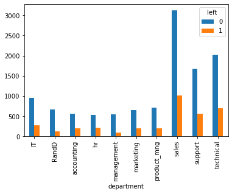

```python
pd.crosstab(hr.department,hr.left).plot(kind='bar')
```

Assigning numeric values to categorical data.

```python
salary = {"low":  0, "medium": 1, "high":2}
salary
```

```
{'low': 0, 'medium': 1, 'high': 2}
```

```python
hr1= hr.replace(salary)
```

```python
department={}
cnt = 0
for dpt in hr1.department.unique():
    department[dpt] = cnt
    cnt += 1
department
```

```
{'sales': 0,
 'accounting': 1,
 'hr': 2,
 'technical': 3,
 'support': 4,
 'management': 5,
 'IT': 6,
 'product_mng': 7,
 'marketing': 8,
 'RandD': 9}
```

```python
hr1= hr1.replace(department)
hr1
```

|  | satisfaction_level | last_evaluation | number_of_projects | average_monthly_hours | years_at_company | work_accident | left | promotion_last_5years | department | salary |
| --- | --- | --- | --- | --- | --- | --- | --- | --- | --- | --- |
| 0 | 0.38 | 0.53 | 2 | 157 | 3 | 0 | 1 | 0 | 0 | 0 |
| 1 | 0.80 | 0.86 | 5 | 262 | 6 | 0 | 1 | 0 | 0 | 1 |
| 2 | 0.11 | 0.88 | 7 | 272 | 4 | 0 | 1 | 0 | 0 | 1 |
| 3 | 0.72 | 0.87 | 5 | 223 | 5 | 0 | 1 | 0 | 0 | 0 |
| 4 | 0.37 | 0.52 | 2 | 159 | 3 | 0 | 1 | 0 | 0 | 0 |
| ... | ... | ... | ... | ... | ... | ... | ... | ... | ... | ... |
| 14994 | 0.40 | 0.57 | 2 | 151 | 3 | 0 | 1 | 0 | 4 | 0 |
| 14995 | 0.37 | 0.48 | 2 | 160 | 3 | 0 | 1 | 0 | 4 | 0 |
| 14996 | 0.37 | 0.53 | 2 | 143 | 3 | 0 | 1 | 0 | 4 | 0 |
| 14997 | 0.11 | 0.96 | 6 | 280 | 4 | 0 | 1 | 0 | 4 | 0 |
| 14998 | 0.37 | 0.52 | 2 | 158 | 3 | 0 | 1 | 0 | 4 | 0 |

14999 rows × 10 columns

Number of employees who retained the job

```python
ret = hr[hr.left==0]
ret.shape
```

```
(11428, 10)
```

Salary-wise analysis of people leaving the job.

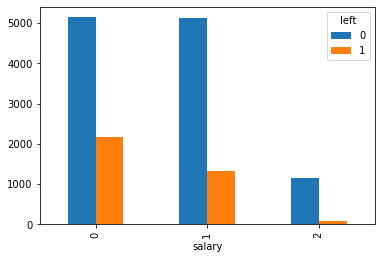

```python
pd.crosstab(hr1.salary,hr1.left).plot(kind='bar')
```

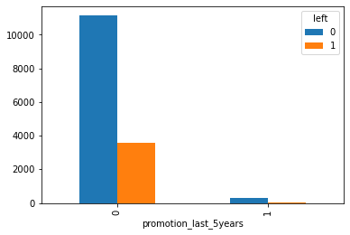

```python
pd.crosstab(hr1.promotion_last_5years,hr1.left).plot(kind='bar')
```

Perform Bivariate analysis

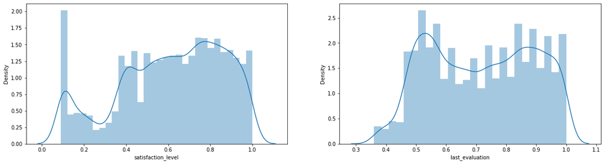

```python
plt.figure(figsize=(20,5))
plt.subplot(121)
sns.distplot(hr['satisfaction_level'])
plt.subplot(122)
sns.distplot(hr['last_evaluation'])
plt.show()
```

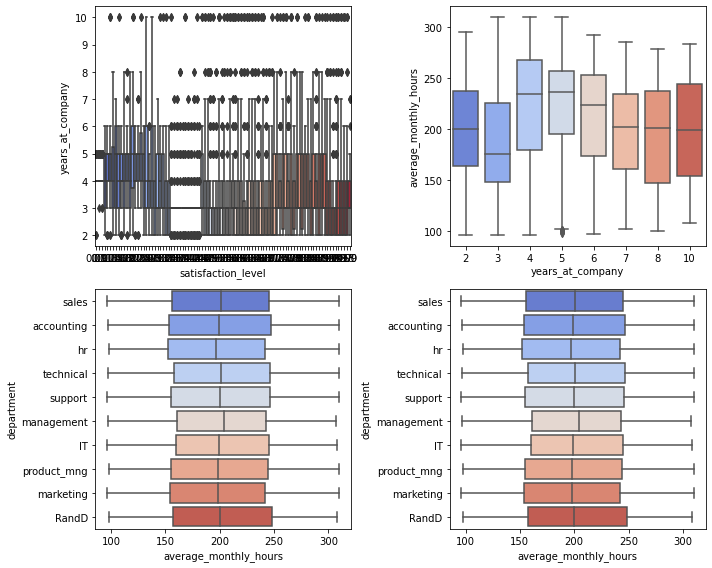

```python
fig, axs = plt.subplots(2,2, figsize=(10,8))
sns.boxplot(x=hr['satisfaction_level'], y=hr['years_at_company'], palette= 'coolwarm', ax = axs[0][0])
sns.boxplot(x=hr['years_at_company'], y=hr['average_monthly_hours'], palette= 'coolwarm', ax = axs[0][1])
sns.boxplot(x=hr['average_monthly_hours'], y=hr['department'], palette= 'coolwarm', ax = axs[1][0])
sns.boxplot(x=hr['average_monthly_hours'], y=hr['department'], palette= 'coolwarm', ax = axs[1][1])
plt.tight_layout()
```

Hypothesis Statements: H0:People left as they were not satified by their jobs H1:People left even if they were satified by their jobs

```python
import scipy.stats as stats
sample=hr1.number_of_projects
stats.ttest_ind(hr1['left'],hr1['satisfaction_level'])
```

```
Ttest_indResult(statistic=-93.06077566920372, pvalue=0.0)
```

Chi-square test

H0:no relation between department and leaving the company H1:relation exists

```python
dept_left=pd.crosstab(hr1.department,hr1.left,margins=True)
```

```python
from scipy import stats

chi_stat,pval,dof,expected_values=stats.chi2_contingency(dept_left)
print(chi_stat)
```

```
86.82547426790299
```

```python
print(pval)
```

```
2.646693771399348e-10
```

```python
if pval>=0.05:
    print('reject H0')
else:
    print('accept H0')
```

[output not shown]

Logistic Regression

```python
from sklearn.linear_model import LogisticRegression
model = LogisticRegression()
from sklearn.model_selection import train_test_split
```

Split the data into training and testing in the ratio of (80:20).

```python
X=hr1.drop(['left'],axis=1)
y=hr1['left']
y.unique()
X_train, X_test, y_train, y_test = train_test_split(X, y, test_size=0.20)
```

```python
model.fit(X_train,y_train)
```

```
LogisticRegression()
```

```python
model.predict(X_test)
```

```
array([0, 0, 0, ..., 0, 0, 1], dtype=int64)
```

```python
model.score(X_test,y_test)
```

```
0.7863333333333333
```

Decision Tree Model

```python
from sklearn.tree import DecisionTreeClassifier
from sklearn.metrics import precision_score,accuracy_score,confusion_matrix,f1_score,recall_score
from sklearn.metrics import classification_report
```

```python
dtree=DecisionTreeClassifier()
dtree.fit(X_train,y_train)
pred_dt=dtree.predict(X_test)
acc_DT=confusion_matrix(pred_dt,y_test)
print(acc_DT)
print(classification_report(pred_dt,y_test))
```

```
[[2224   27]
 [  43  706]]
              precision    recall  f1-score   support

           0       0.98      0.99      0.98      2251
           1       0.96      0.94      0.95       749

    accuracy                           0.98      3000
   macro avg       0.97      0.97      0.97      3000
weighted avg       0.98      0.98      0.98      3000
```

Accuracy score of DT model is 98%

From the analysis, it is observed that Decision Tree is a better model because of better accuracy.

Hyperparameter-

```python
hr1.satisfaction_level=hr1.satisfaction_level*10
```

```python
hr1.last_evaluation=hr1.last_evaluation*10
```

```python
X=hr1
X_train, X_test, y_train, y_test = train_test_split(X, y, test_size=0.20)
```

```python
model.fit(X_train,y_train)
```

```python
model.predict(X_test)
```

[output not shown]

```python
model.score(X_test,y_test)
```

[output not shown]

```python
model.predict_proba(X_test)
```

[output not shown]